#1. Defining the Question

##a.Specifying the data analytic question `Identify which individuals are most likely to click on ads.`

##b) Defining the metric of success `When we are able to identify the individuals likely to click on ads based on the information and data given.`

##c) Understanding the context `A Kenyan entrepreneur has created an online cryptography course and would want to advertise it on her blog. She currently targets audiences originating from various countries. In the past, she ran ads to advertise a related course on the same blog and collected data in the process. She would now like to employ my services as a Data Science Consultant to help her identify which individuals are most likely to click on her ads.`

##d) Recording the experimental design ```The process will entail: * Define the question, the metric for success, the context, experimental design taken.

- Read and explore the given dataset.
- Define the appropriateness of the available data to answer the given question.
- Find and deal with outliers, anomalies, and missing data within the dataset.
- Perform univariate and bivariate analysis recording my observations.```

##e) Data Relevance

```The data provided is very relevant and has a wide range of variables to consider in achieving our main objective of this project.

[Advertising dataset](http://bit.ly/IPAdvertisingData)```

#2. Reading the Data

```r
# Loading our data set
advertising <- read.csv('advertising.csv')
```

#3. Checking the data

```r
# Viewing the top 6 entries
head(advertising)
```

```
##   Daily.Time.Spent.on.Site Age Area.Income Daily.Internet.Usage
## 1                    68.95  35    61833.90               256.09
## 2                    80.23  31    68441.85               193.77
## 3                    69.47  26    59785.94               236.50
## 4                    74.15  29    54806.18               245.89
## 5                    68.37  35    73889.99               225.58
## 6                    59.99  23    59761.56               226.74
##                           Ad.Topic.Line           City Male    Country
## 1    Cloned 5thgeneration orchestration    Wrightburgh    0    Tunisia
## 2    Monitored national standardization      West Jodi    1      Nauru
## 3      Organic bottom-line service-desk       Davidton    0 San Marino
## 4 Triple-buffered reciprocal time-frame West Terrifurt    1      Italy
## 5         Robust logistical utilization   South Manuel    0    Iceland
## 6       Sharable client-driven software      Jamieberg    1     Norway
##             Timestamp Clicked.on.Ad
## 1 2016-03-27 00:53:11             0
## 2 2016-04-04 01:39:02             0
## 3 2016-03-13 20:35:42             0
## 4 2016-01-10 02:31:19             0
## 5 2016-06-03 03:36:18             0
## 6 2016-05-19 14:30:17             0
```

```r
#viewing the whole data set
View(advertising)

#Data types of the columns
str(advertising)
```

```
## 'data.frame':    1000 obs. of  10 variables:
##  $ Daily.Time.Spent.on.Site: num  69 80.2 69.5 74.2 68.4 ...
##  $ Age                     : int  35 31 26 29 35 23 33 48 30 20 ...
##  $ Area.Income             : num  61834 68442 59786 54806 73890 ...
##  $ Daily.Internet.Usage    : num  256 194 236 246 226 ...
##  $ Ad.Topic.Line           : chr  "Cloned 5thgeneration orchestration" "Monitored national standardization" "Organic bottom-line service-desk" "Triple-buffered reciprocal time-frame" ...
##  $ City                    : chr  "Wrightburgh" "West Jodi" "Davidton" "West Terrifurt" ...
##  $ Male                    : int  0 1 0 1 0 1 0 1 1 1 ...
##  $ Country                 : chr  "Tunisia" "Nauru" "San Marino" "Italy" ...
##  $ Timestamp               : chr  "2016-03-27 00:53:11" "2016-04-04 01:39:02" "2016-03-13 20:35:42" "2016-01-10 02:31:19" ...
##  $ Clicked.on.Ad           : int  0 0 0 0 0 0 0 1 0 0 ...
```

```r
#Statistical summary of the data set
summary(advertising)
```

```
##  Daily.Time.Spent.on.Site      Age         Area.Income    Daily.Internet.Usage
##  Min.   :32.60            Min.   :19.00   Min.   :13996   Min.   :104.8
##  1st Qu.:51.36            1st Qu.:29.00   1st Qu.:47032   1st Qu.:138.8
##  Median :68.22            Median :35.00   Median :57012   Median :183.1
##  Mean   :65.00            Mean   :36.01   Mean   :55000   Mean   :180.0
##  3rd Qu.:78.55            3rd Qu.:42.00   3rd Qu.:65471   3rd Qu.:218.8
##  Max.   :91.43            Max.   :61.00   Max.   :79485   Max.   :270.0
##  Ad.Topic.Line          City                Male         Country
##  Length:1000        Length:1000        Min.   :0.000   Length:1000
##  Class :character   Class :character   1st Qu.:0.000   Class :character
##  Mode  :character   Mode  :character   Median :0.000   Mode  :character
##                                        Mean   :0.481
##                                        3rd Qu.:1.000
##                                        Max.   :1.000
##   Timestamp         Clicked.on.Ad
##  Length:1000        Min.   :0.0
##  Class :character   1st Qu.:0.0
##  Mode  :character   Median :0.5
##                     Mean   :0.5
##                     3rd Qu.:1.0
##                     Max.   :1.0
```

```r
#checking the number of entries and attributes
dim(advertising)
```

```
## [1] 1000   10
```

```r
#checking the class of our object
class(advertising)
```

```
## [1] "data.frame"
```

#4. Tidying the data/ Data Cleaning

`*Checking for missing data*`

```r
#Checking for missing data
colSums(is.na(advertising))
```

```
## Daily.Time.Spent.on.Site                      Age              Area.Income
##                        0                        0                        0
##     Daily.Internet.Usage            Ad.Topic.Line                     City
##                        0                        0                        0
##                     Male                  Country                Timestamp
##                        0                        0                        0
##            Clicked.on.Ad
##                        0
```

`There are no missing values in our data set.`

`*Checking for duplicates*`

```r
duplicated.rows <- advertising[duplicated(advertising),]
duplicated.rows
```

```
##  [1] Daily.Time.Spent.on.Site Age                      Area.Income
##  [4] Daily.Internet.Usage     Ad.Topic.Line            City
##  [7] Male                     Country                  Timestamp
## [10] Clicked.on.Ad
## <0 rows> (or 0-length row.names)
```

`There is no duplicated data in our dataset`

`*Checking for outliers*`

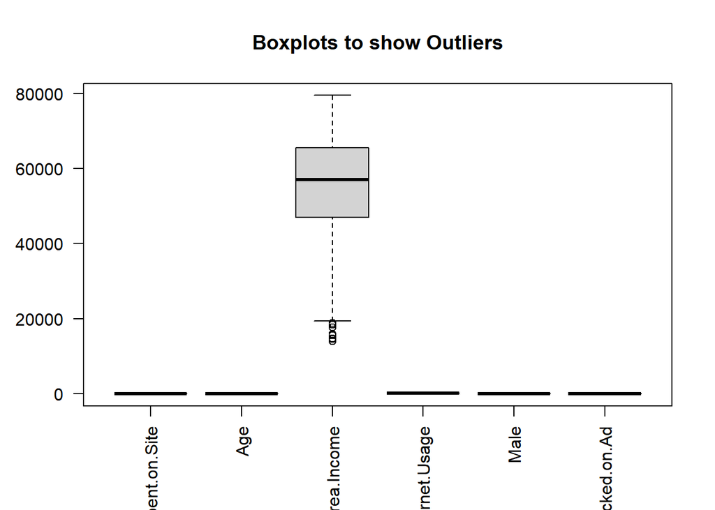

```r
#Create a list of numeric columns
num.cols <- list(advertising$Daily.Time.Spent.on.Site,advertising$Age,
advertising$Area.Income,advertising$Daily.Internet.Usage,advertising$Male, advertising$Clicked.on.Ad)

#Checking for outliers
boxplot(num.cols, names=c('Daily.Time.Spent.on.Site', 'Age', 'Area.Income', 'Daily.Internet.Usage', 'Male', 'Clicked.on.Ad'), main='Boxplots to show Outliers', las=2)
```

```r
#Listing the outliers
boxplot.stats(advertising$Area.Income)$out
```

```
## [1] 17709.98 18819.34 15598.29 15879.10 14548.06 13996.50 14775.50 18368.57
```

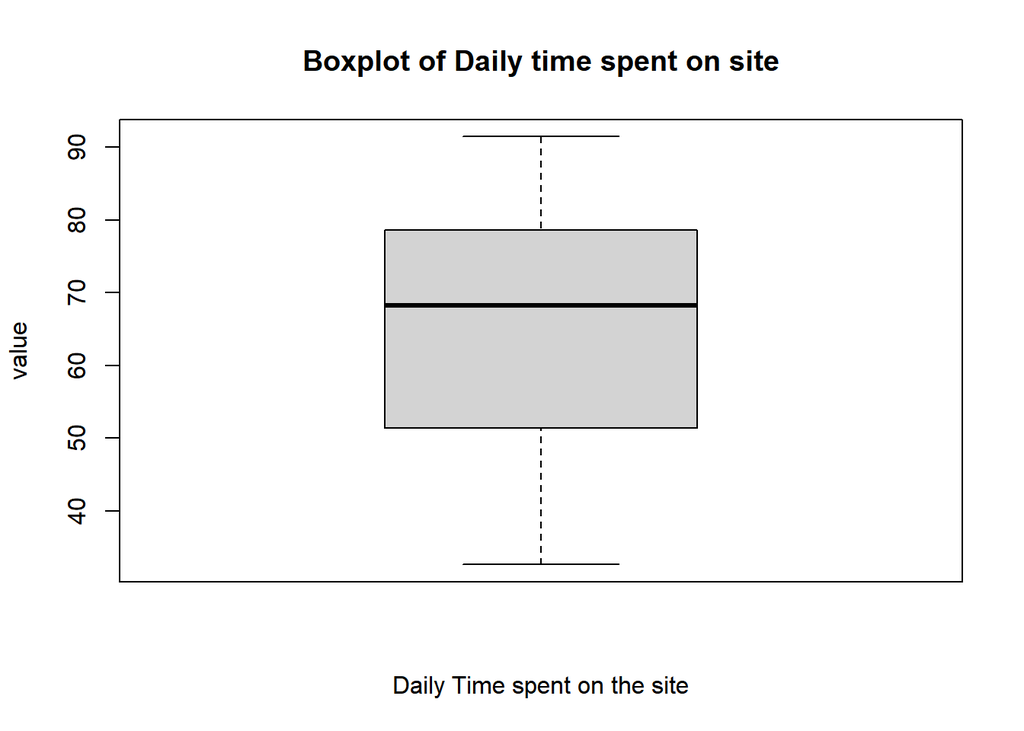

```r
#Plotting boxplots of individual columns

boxplot(advertising$Daily.Time.Spent.on.Site, main='Boxplot of Daily time spent on site', xlab='Daily Time spent on the site', ylab='value')
```

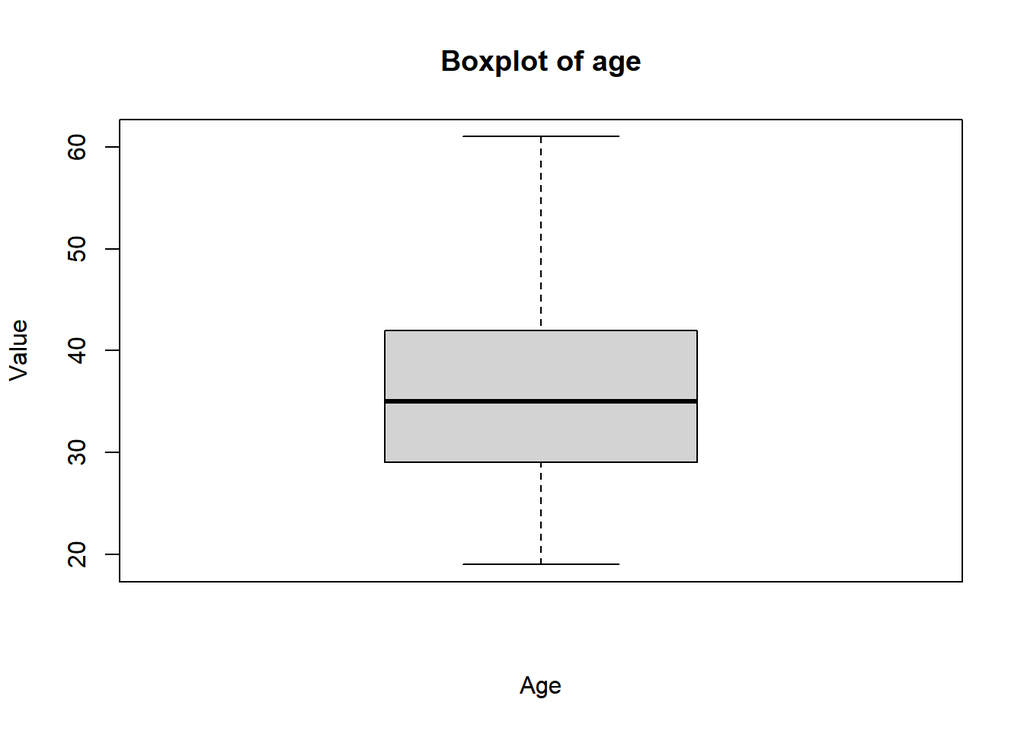

```r
boxplot(advertising$Age, main='Boxplot of age', xlab='Age', ylab='Value')
```

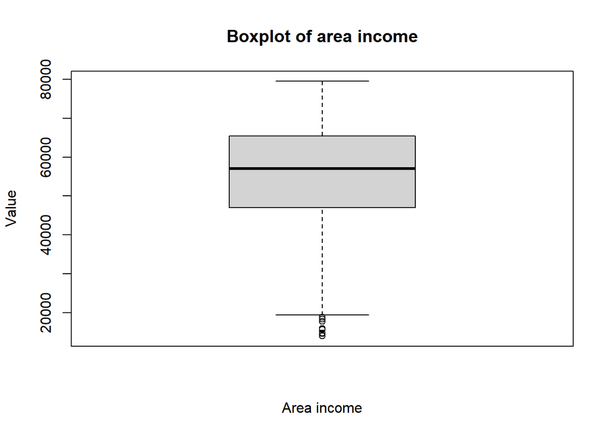

```r
boxplot(advertising$Area.Income, main='Boxplot of area income', xlab='Area income', ylab='Value')
```

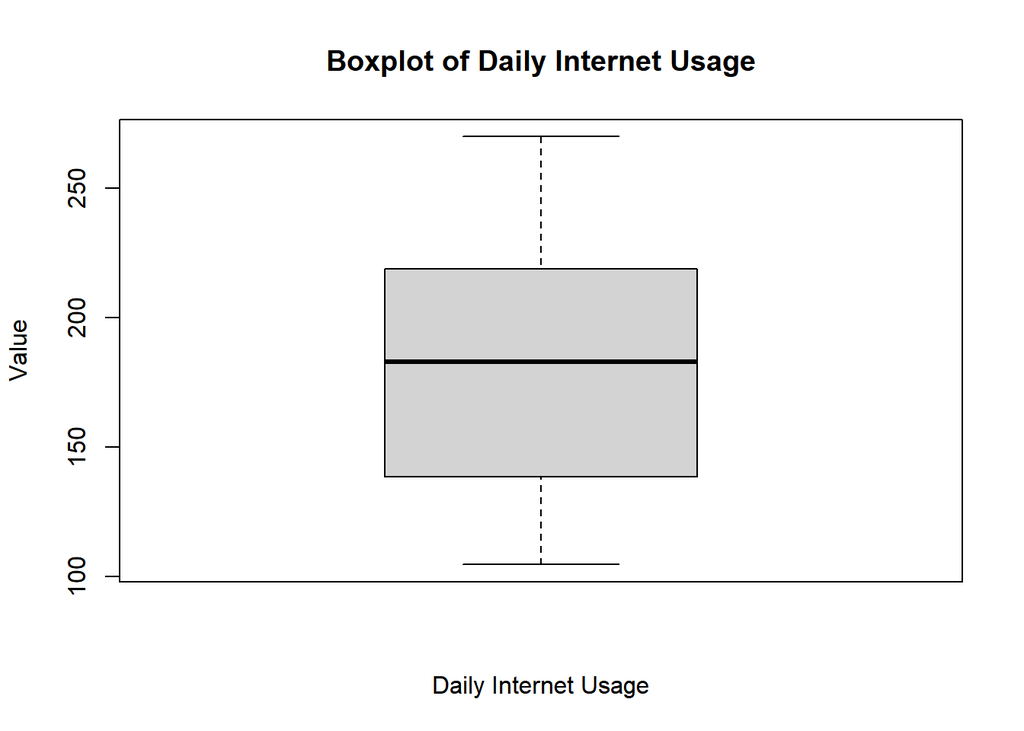

```r
boxplot(advertising$Daily.Internet.Usage, main='Boxplot of Daily Internet Usage', xlab='Daily Internet Usage', ylab='Value')
```

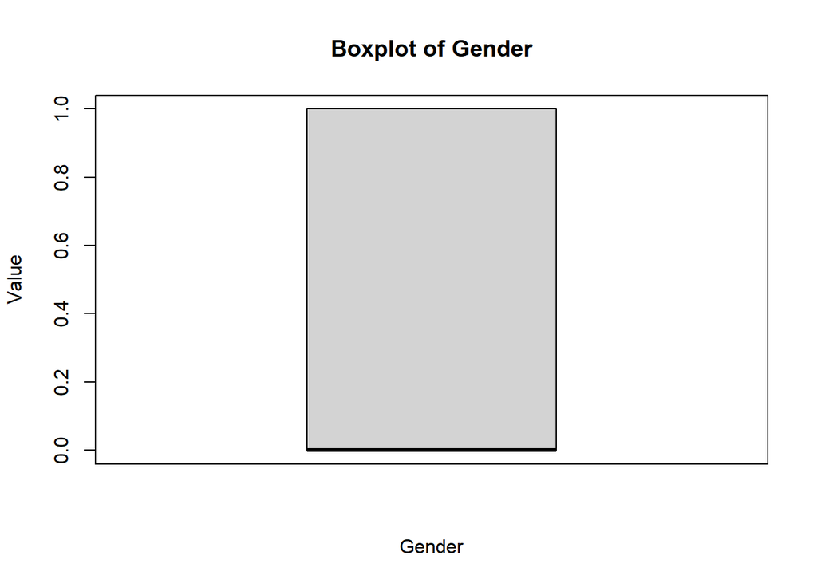

```r
boxplot(advertising$Male, main='Boxplot of Gender', xlab='Gender', ylab='Value')
```

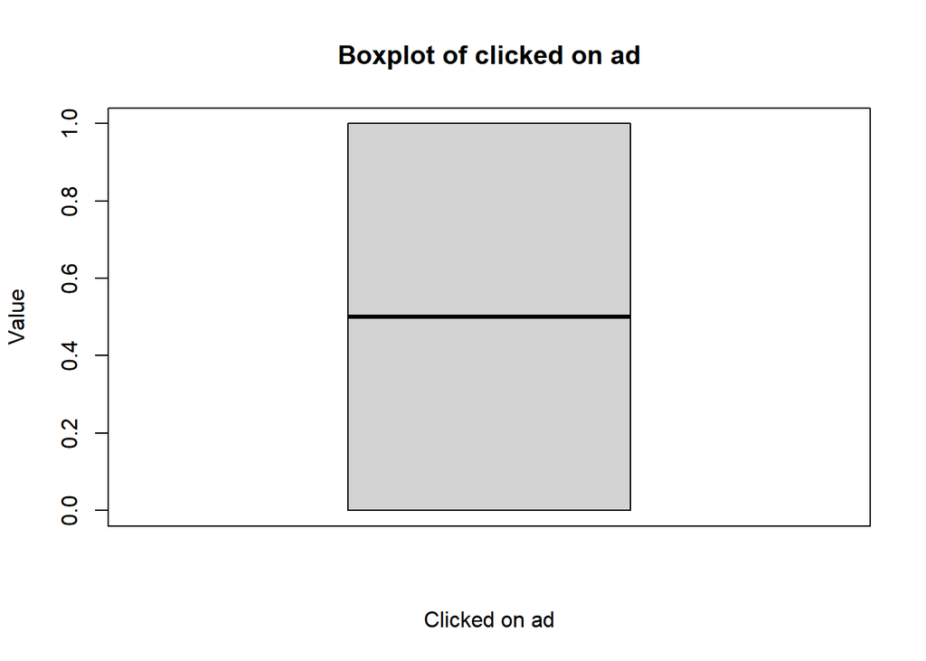

```r
boxplot(advertising$Clicked.on.Ad, main='Boxplot of clicked on ad', xlab='Clicked on ad', ylab='Value')
```

`The outliers in area income might be due to low numbers of add clicks so no need to remove them.`

#5 Univariate Exploratory Data Analysis ## Measures of Central Tendancy

```r
#Finding the mean
colMeans(advertising[sapply(advertising, is.numeric)])
```

```
## Daily.Time.Spent.on.Site                      Age              Area.Income
##                  65.0002                  36.0090               55000.0001
##     Daily.Internet.Usage                     Male            Clicked.on.Ad
##                 180.0001                   0.4810                   0.5000
```

```r
#Finding the median
#loading the tidyverse and robustbase(for the colMedians function) libraries
library(robustbase)
library(tidyverse)
advertising%>%
  select_if(is.numeric) %>%
  as.matrix()%>%
  colMedians()
```

```
## Daily.Time.Spent.on.Site                      Age              Area.Income
##                   68.215                   35.000                57012.300
##     Daily.Internet.Usage                     Male            Clicked.on.Ad
##                  183.130                    0.000                    0.500
```

```r
#Finding the mode
mode <- function(x) {
  uniq_data <- unique(x)
  map_data <- match(x, uniq_data)
  tab_data <- tabulate(map_data)
  max_val <- max(tab_data)
  uniq_data[tab_data == max_val]
}

mode(advertising$Daily.Time.Spent.on.Site)
```

```
## [1] 62.26 75.55 84.53 77.05 78.76
```

```r
mode(advertising$Age)
```

```
## [1] 31
```

```r
mode(advertising$Area.Income)
```

[output not shown]

[output cut: 110 more lines]

```r
mode(advertising$Daily.Internet.Usage)
```

```
##  [1] 167.22 125.45 119.30 120.06 113.53 115.91 138.35 158.22 235.28 194.23
## [11] 211.87 222.11 162.44 219.72 214.42 234.75 178.75 161.16 201.15 169.40
## [21] 135.24 228.81 230.36 256.40 117.30 223.16 215.18 136.18 164.25 182.65
## [31] 247.05 190.95 132.38 236.96
```

```r
mode(advertising$Ad.Topic.Line)
```

[output not shown]

[output cut: 985 more lines]

```r
mode(advertising$City)
```

```
## [1] "Lisamouth"    "Williamsport"
```

```r
mode(advertising$Male)
```

```
## [1] 0
```

```r
mode(advertising$Country)
```

```
## [1] "Czech Republic" "France"
```

```r
mode(advertising$Timestamp)
```

[output not shown]

[output cut: 319 more lines]

```r
mode(advertising$Clicked.on.Ad)
```

```
## [1] 0 1
```

## Measures of Dispersion

```r
#Finding the minimum
num.cols <- list(advertising$Daily.Time.Spent.on.Site,advertising$Age,
advertising$Area.Income,advertising$Daily.Internet.Usage,advertising$Male, advertising$Clicked.on.Ad)

min(advertising$Daily.Time.Spent.on.Site)
```

```
## [1] 32.6
```

```r
min(advertising$Age)
```

```
## [1] 19
```

```r
min(advertising$Area.Income)
```

```
## [1] 13996.5
```

```r
min(advertising$Daily.Internet.Usage)
```

```
## [1] 104.78
```

```r
min(advertising$Male)
```

```
## [1] 0
```

```r
min(advertising$Clicked.on.Ad)
```

```
## [1] 0
```

```r
#Finding the maximum
max(advertising$Daily.Time.Spent.on.Site)
```

```
## [1] 91.43
```

```r
max(advertising$Age)
```

```
## [1] 61
```

```r
max(advertising$Area.Income)
```

```
## [1] 79484.8
```

```r
max(advertising$Daily.Internet.Usage)
```

```
## [1] 269.96
```

```r
max(advertising$Male)
```

```
## [1] 1
```

```r
max(advertising$Clicked.on.Ad)
```

```
## [1] 1
```

```r
#Finding the Range
range(advertising$Daily.Time.Spent.on.Site)
```

```
## [1] 32.60 91.43
```

```r
range(advertising$Age)
```

```
## [1] 19 61
```

```r
range(advertising$Area.Income)
```

```
## [1] 13996.5 79484.8
```

```r
range(advertising$Daily.Internet.Usage)
```

```
## [1] 104.78 269.96
```

```r
range(advertising$Male)
```

```
## [1] 0 1
```

```r
range(advertising$Clicked.on.Ad)
```

```
## [1] 0 1
```

```r
#Finding the quantiles
quantile(advertising$Daily.Time.Spent.on.Site)
```

```
##      0%     25%     50%     75%    100%
## 32.6000 51.3600 68.2150 78.5475 91.4300
```

```r
quantile(advertising$Age)
```

```
##   0%  25%  50%  75% 100%
##   19   29   35   42   61
```

```r
quantile(advertising$Area.Income)
```

```
##       0%      25%      50%      75%     100%
## 13996.50 47031.80 57012.30 65470.64 79484.80
```

```r
quantile(advertising$Daily.Internet.Usage)
```

```
##       0%      25%      50%      75%     100%
## 104.7800 138.8300 183.1300 218.7925 269.9600
```

```r
quantile(advertising$Male)
```

```
##   0%  25%  50%  75% 100%
##    0    0    0    1    1
```

```r
quantile(advertising$Clicked.on.Ad)
```

```
##   0%  25%  50%  75% 100%
##  0.0  0.0  0.5  1.0  1.0
```

```r
#Finding the variance
var(advertising$Daily.Time.Spent.on.Site)
```

```
## [1] 251.3371
```

```r
var(advertising$Age)
```

```
## [1] 77.18611
```

```r
var(advertising$Area.Income)
```

```
## [1] 179952406
```

```r
var(advertising$Daily.Internet.Usage)
```

```
## [1] 1927.415
```

```r
var(advertising$Male)
```

```
## [1] 0.2498889
```

```r
var(advertising$Clicked.on.Ad)
```

```
## [1] 0.2502503
```

```r
#Finding the Standard Deviation
sd(advertising$Daily.Time.Spent.on.Site)
```

```
## [1] 15.85361
```

```r
sd(advertising$Age)
```

```
## [1] 8.785562
```

```r
sd(advertising$Area.Income)
```

```
## [1] 13414.63
```

```r
sd(advertising$Daily.Internet.Usage)
```

```
## [1] 43.90234
```

```r
sd(advertising$Male)
```

```
## [1] 0.4998889
```

```r
sd(advertising$Clicked.on.Ad)
```

```
## [1] 0.5002502
```

## Univariate Data analysis Graphicals

```r
#Creating a frequency table for city
city <- advertising$City
freq_city <- table(city)
freq_city
```

[output not shown]

[output cut: 592 more lines]

```
##                       1                       1                       1
##             Whitneyfort              Wilcoxport            Williammouth
##                       1                       1                       1
##             Williamport         Williamsborough            Williamsfort
##                       1                       1                       1
##           Williamsmouth            Williamsport            Williamsside
##                       1                       3                       1
##             Williamstad             Wilsonburgh             Wintersfort
##                       1                       1                       1
##                Wongland             Wrightburgh              Wrightview
##                       1                       2                       1
##                Yangside              Youngburgh               Youngfort
##                       1                       1                       1
##                   Yuton             Zacharystad              Zacharyton
##                       1                       1                       1
```

```r
#Creating a frequency table for country
country <- advertising$Country
freq_country <- table(country)
freq_country
```

[output not shown]

[output cut: 420 more lines]

```
##                                                   6
##                                           Venezuela
##                                                   7
##                                             Vietnam
##                                                   3
##                                   Wallis and Futuna
##                                                   4
##                                      Western Sahara
##                                                   7
##                                               Yemen
##                                                   3
##                                              Zambia
##                                                   4
##                                            Zimbabwe
##                                                   6
```

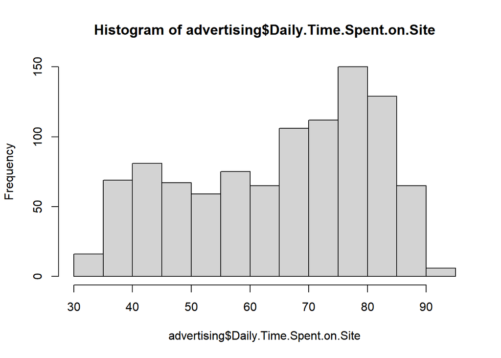

```r
#Creating a histogram for daily time spent on site
hist(advertising$Daily.Time.Spent.on.Site)
```

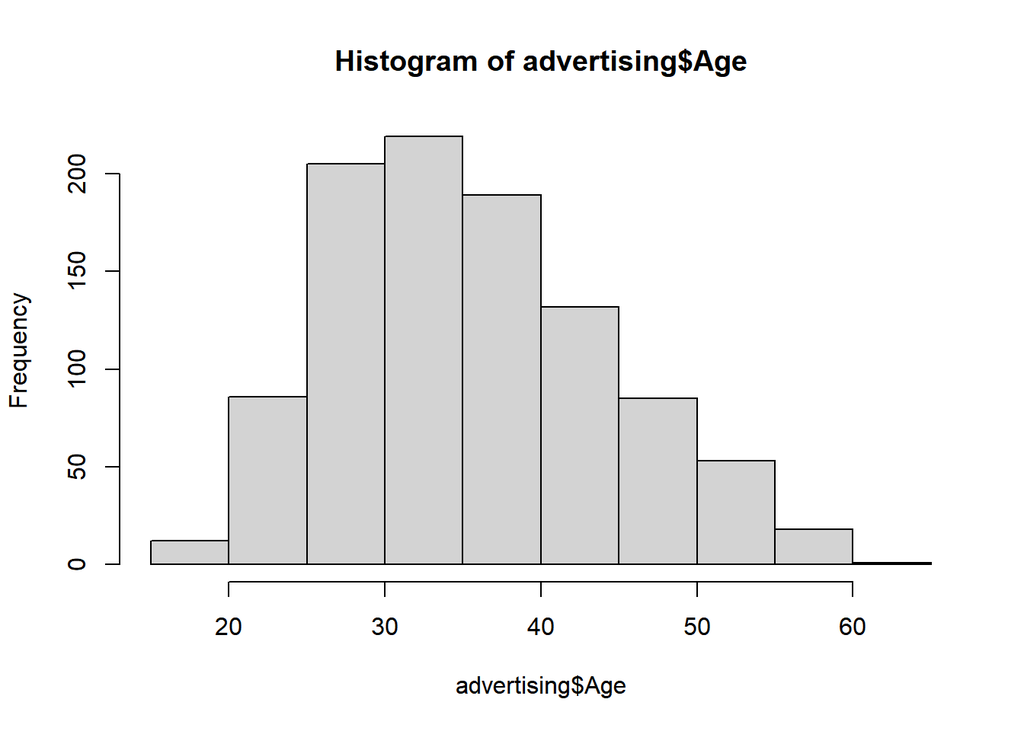

```r
#Creating a histogram for age
hist(advertising$Age)
```

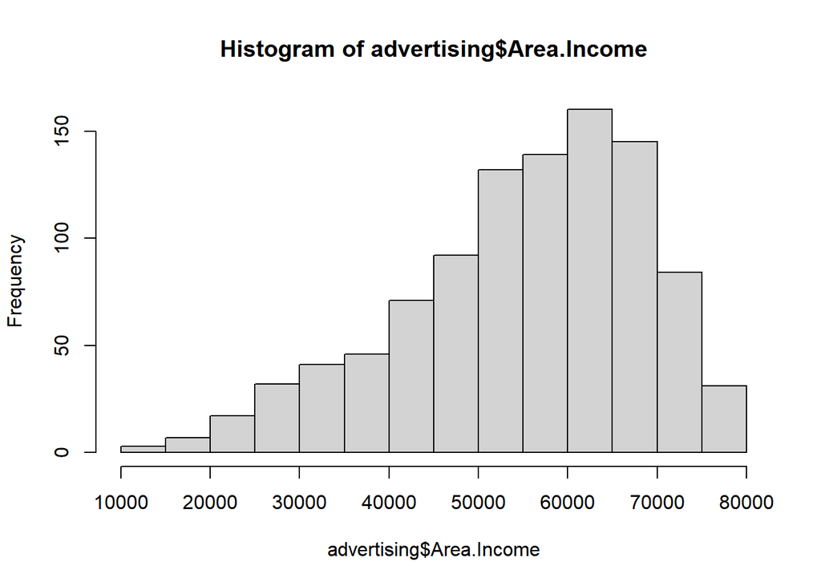

```r
#Creating a histogram for Area Income
hist(advertising$Area.Income)
```

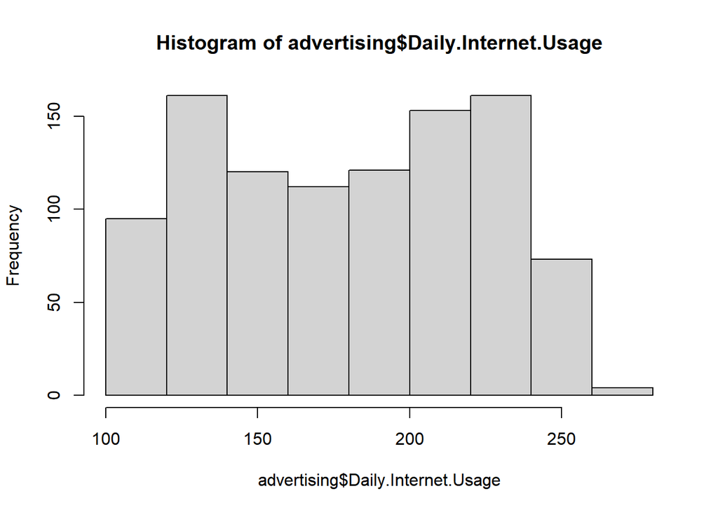

```r
#Creating a histogram of daily internet usage
hist(advertising$Daily.Internet.Usage)
```

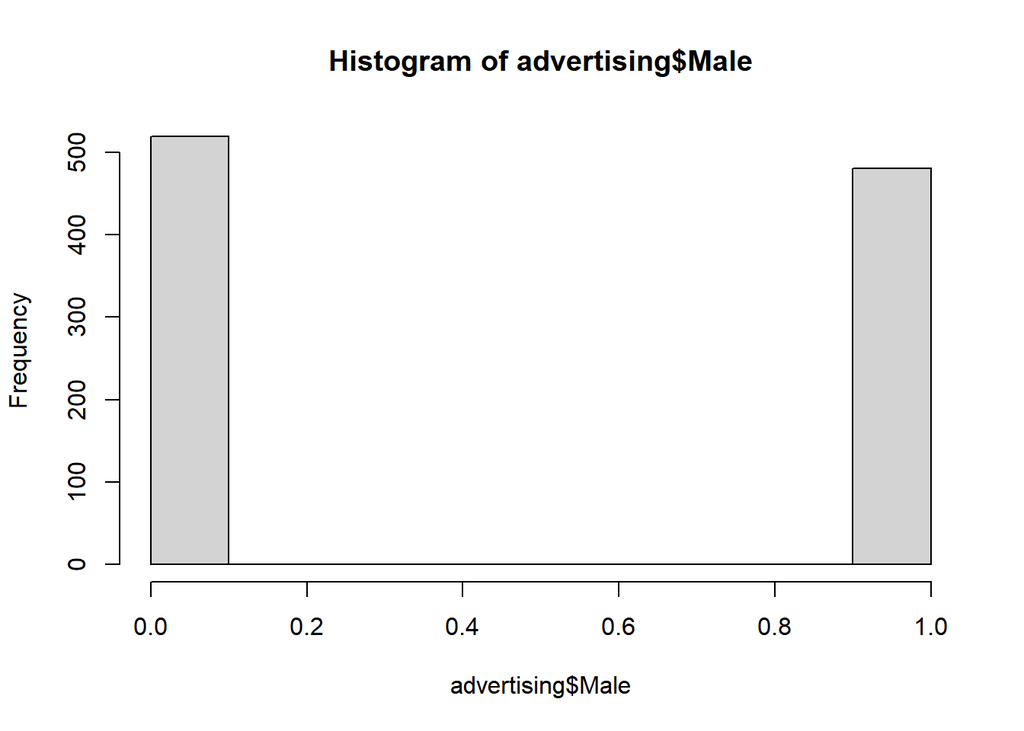

```r
#Creating a histogram for Male
hist(advertising$Male)
```

```r
#Frequency table of Male
table(advertising$Male)
```

```
##
##   0   1
## 519 481
```

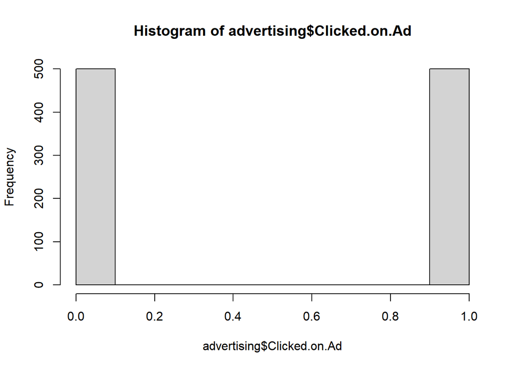

```r
#Creating a histogram for clicked on ad
hist(advertising$Clicked.on.Ad)
```

```r
#Frequency table of clicked on ad
table(advertising$Clicked.on.Ad)
```

```
##
##   0   1
## 500 500
```

### Observations from Univariate Analysis

[output not shown]

#6. Bivariate and Multivariate Data Analysis

```r
#Finding the covariance
cov <- cov(advertising[, unlist(lapply(advertising, is.numeric))])
round(cov, 3)
```

```
##                          Daily.Time.Spent.on.Site        Age   Area.Income
## Daily.Time.Spent.on.Site                  251.337    -46.174     66130.811
## Age                                       -46.174     77.186    -21520.926
## Area.Income                             66130.811 -21520.926 179952405.952
## Daily.Internet.Usage                      360.992   -141.635    198762.532
## Male                                       -0.150     -0.092         8.868
## Clicked.on.Ad                              -5.933      2.165     -3195.989
##                          Daily.Internet.Usage   Male Clicked.on.Ad
## Daily.Time.Spent.on.Site              360.992 -0.150        -5.933
## Age                                  -141.635 -0.092         2.165
## Area.Income                        198762.532  8.868     -3195.989
## Daily.Internet.Usage                 1927.415  0.615       -17.274
## Male                                    0.615  0.250        -0.010
## Clicked.on.Ad                         -17.274 -0.010         0.250
```

```r
#Finding the correlation
cor <- cor(advertising[, unlist(lapply(advertising, is.numeric))])
round(cor, 3)
```

```
##                          Daily.Time.Spent.on.Site    Age Area.Income
## Daily.Time.Spent.on.Site                    1.000 -0.332       0.311
## Age                                        -0.332  1.000      -0.183
## Area.Income                                 0.311 -0.183       1.000
## Daily.Internet.Usage                        0.519 -0.367       0.337
## Male                                       -0.019 -0.021       0.001
## Clicked.on.Ad                              -0.748  0.493      -0.476
##                          Daily.Internet.Usage   Male Clicked.on.Ad
## Daily.Time.Spent.on.Site                0.519 -0.019        -0.748
## Age                                    -0.367 -0.021         0.493
## Area.Income                             0.337  0.001        -0.476
## Daily.Internet.Usage                    1.000  0.028        -0.787
## Male                                    0.028  1.000        -0.038
## Clicked.on.Ad                          -0.787 -0.038         1.000
```

## Bivariate and Multivariate Graphicals

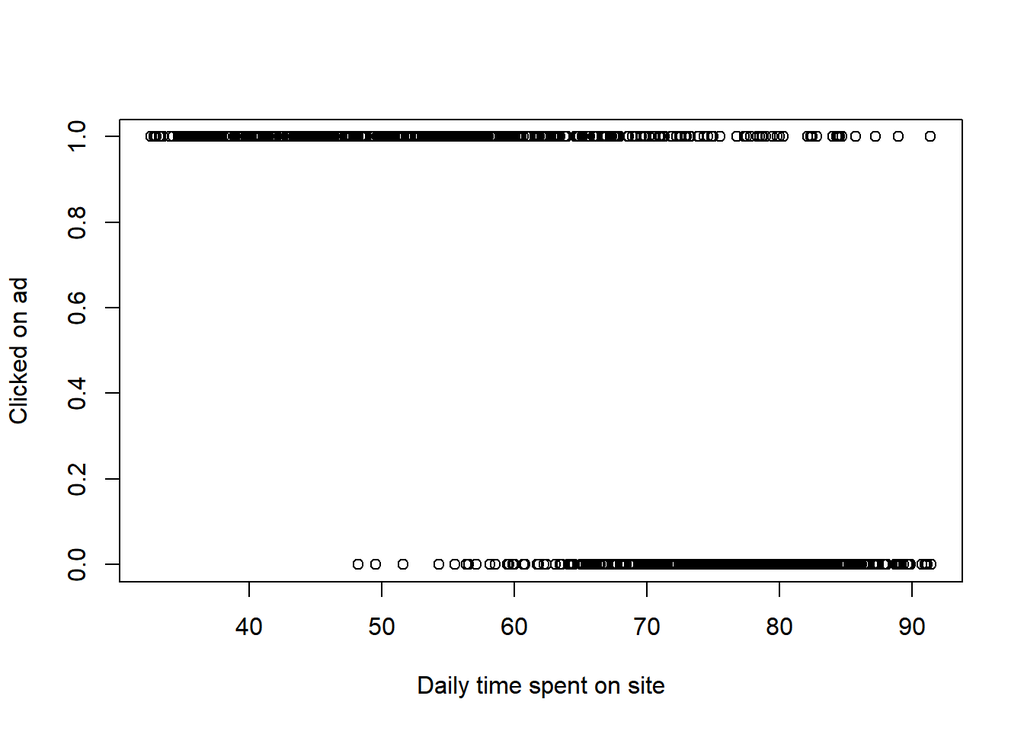

```r
#Plotting a scatterplot of daily time spent on site and clicked on ad
#num.cols <- list(advertising$Daily.Time.Spent.on.Site,advertising$Age,
#advertising$Area.Income,advertising$Daily.Internet.Usage,advertising$Male, advertising$Clicked.on.Ad)
daily.time.spent.on.site <- advertising$Daily.Time.Spent.on.Site
clicked.on.ad <- advertising$Clicked.on.Ad

plot(daily.time.spent.on.site, clicked.on.ad, xlab='Daily time spent on site', ylab='Clicked on ad')
```

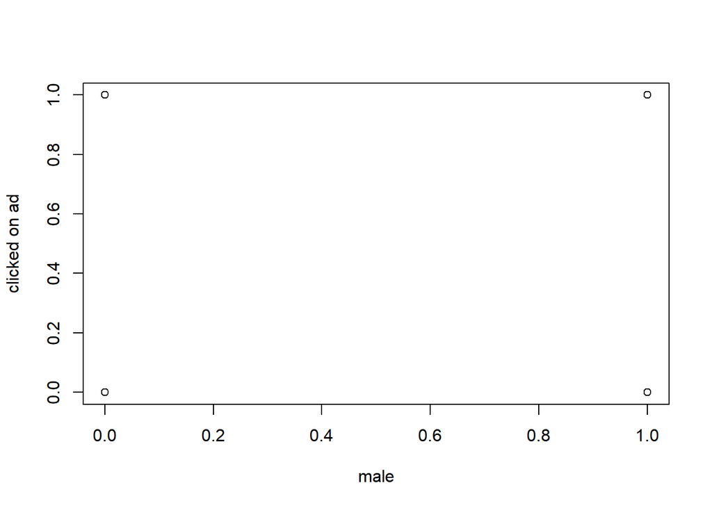

```r
#Plotting a scatter plot of male against clicked on ad
male <- advertising$Male
clicked.on.ad <- advertising$Clicked.on.Ad
plot(male, clicked.on.ad, xlab='male', ylab='clicked on ad')
```

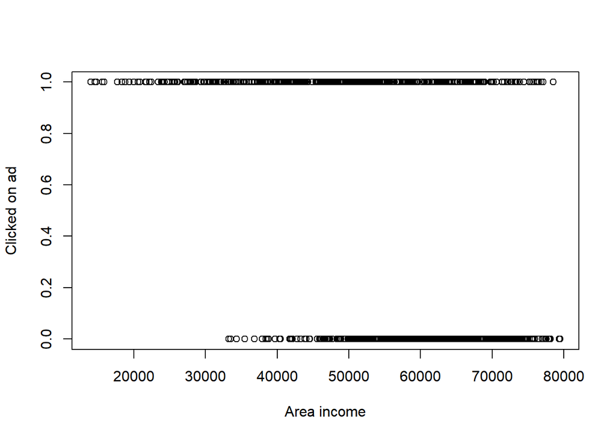

```r
#Plotting area income and clicked on add
area.income <- advertising$Area.Income
clicked.on.ad <- advertising$Clicked.on.Ad
plot(area.income, clicked.on.ad, xlab='Area income', ylab='Clicked on ad')
```

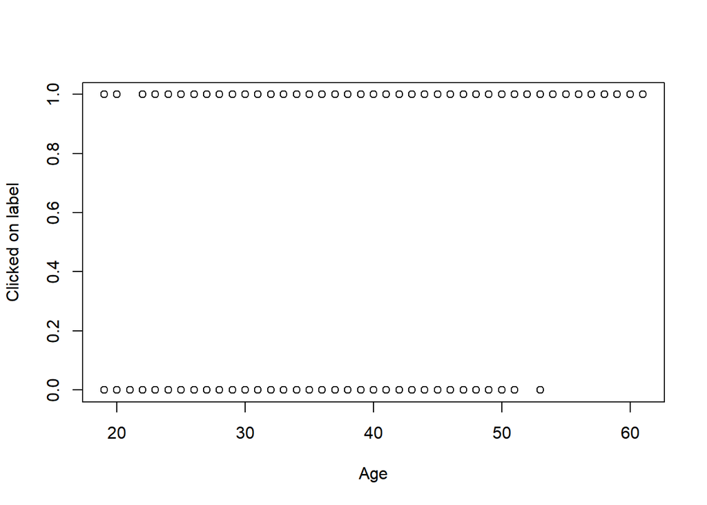

```r
#Plotting scatter plot of age and clicked on ad
age <- advertising$Age
clicked.on.ad <- advertising$Clicked.on.Ad
plot(age, clicked.on.ad, xlab='Age', ylab='Clicked on label')
```

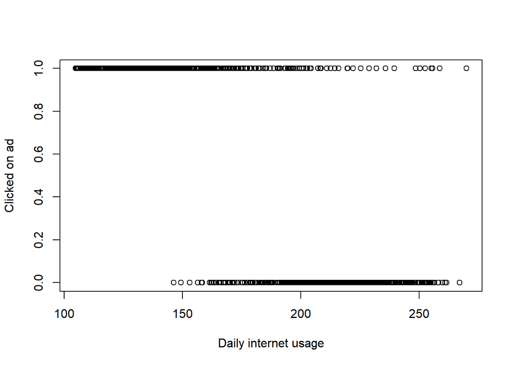

```r
#Plottin scatter plot of daily internet usage and clicked on ad
daily.internet.usage <- advertising$Daily.Internet.Usage
clicked.on.ad <- advertising$Clicked.on.Ad
plot(daily.internet.usage, clicked.on.ad, xlab='Daily internet usage', ylab='Clicked on ad')
```

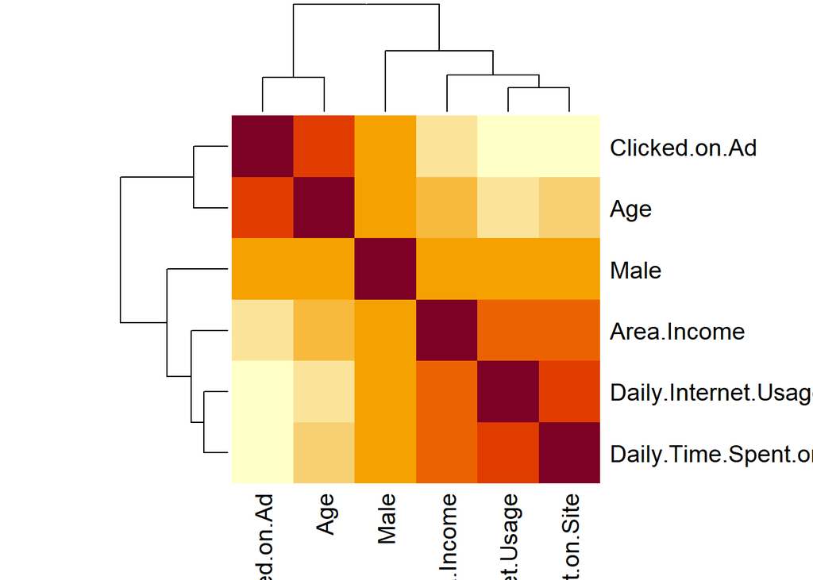

```r
#Plotting a heat map using the correlation matrix
heatmap(x=cor, symm=TRUE)
```

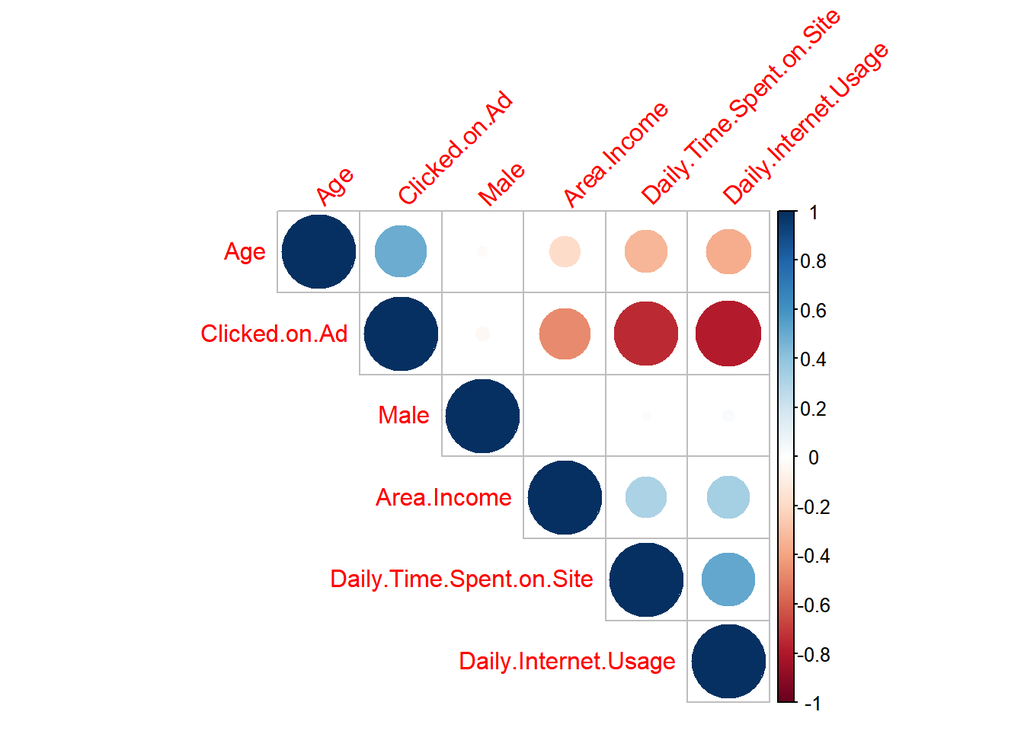

```r
#Plotting a correlogram
library('corrplot')
corrplot(cor, type='upper', order='hclust', tl.color='black', tl.srt=45)
```

### Observations from Bivariate and Multivariate Analysis

```
* Daily internet usage and daily time spent on site are positively correlated.

* Daily time spent on site and Daily Internet usage are negatively correlated to whether an individual clicks on an ad or not.

* There is no strong correlation between male(gender), age, area income and whether an individual clicked on an ad or not.
```

## Conclusion

[output not shown]

## Recommendations

[output not shown]